# BAM Files Solutions

8/27/2018

## GenomicAlignments

The purpose of this exercise is to explore BAM files and the data they contain. We’ll extract the sequences and qualities of aligned reads, and draw simple plots to illustrate their properties.

The dataset is actually part of an R package, [Pasilla dataset](http://bioconductor.org/packages/release/data/experiment/html/pasillaBamSubset.html). It’s already in our workshop folder, so we can install it from there.

```r
install.packages("/home/ace/ace_workshop/ace_bioconductor/pasillaBamSubset_0.18.0.tar.gz", repos=NULL)
```

We will use the **Rsamtools** and **ShortRead** libraries in addition to the **pasillaBamSubset** we just installed.

### Exercises

1. Use `ScanBamParam` to create an object that restricts the information extracted from the BAM file. Restrict the information using `readGAlignments` to select reads that align to the plus strand (isMinusStrand=FALSE). `readGAlignments` inputs alignment information; also arrange to input sequence and quality information using what=c(‘seq’, ‘qual’). You might also find this page useful: [Decoding SAM Flags](https://broadinstitute.github.io/picard/explain-flags.html)

2. Input the sequences and qualities using `readGAlignments`, providing the file path returned by `untreated1_chr4` (a ‘convenience’ function from the **pasillaBamSubset** package) and the ScanBamParam object created in the previous question.

3. Use `alphabetByCycle` to summarize nucleotide use by cycle; plot the relationship between cycle and use. Use alphabetByCycle to summarize nucleotide use by cycle; plot the relationship between cycle and use. Were you expecting this result? What is going on?

Might be a little tricky! Try examining the res object and its `elementMetadata` attribute; also see `?attributes`.

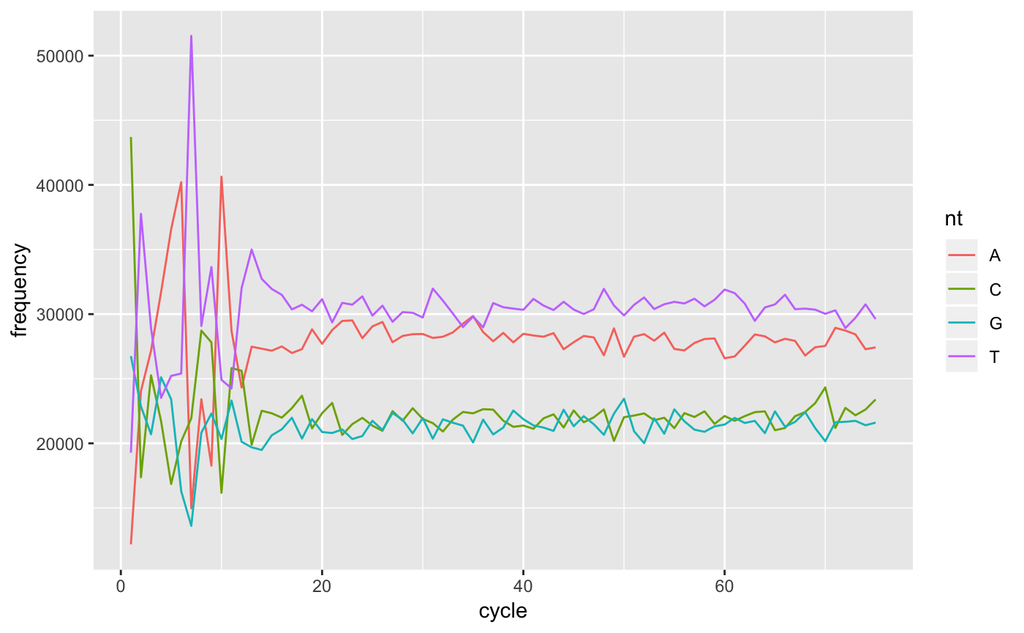

4. Coerce the quality scores to a matrix, and summarize the distribution of qualities across cycle. Is this expected?

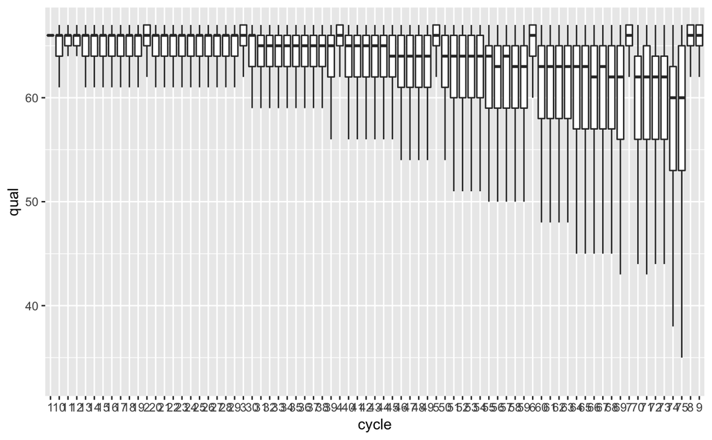